# xwMOOC 모형

예측모형 - 네트워크

xwMOOC

Tidyverse Korea

2018-11-22

# 1 고객/HR 이탈 네트워크 데이터

엑셀파일에 노드와 연결선을 정성스럽게 정한 다음 각 쉬트 데이터를 데이터프레임으로 변환한 후에 `igraph` 팩키지 `graph_from_data_frame()` 함수를 통해 데이터프레임을 네트워크 객체로 불러온다.

```r
library(tidyverse)
library(readxl)
library(igraph)

node_df <- read_excel("data/churn_network.xlsx", sheet="node")
edge_df <- read_excel("data/churn_network.xlsx", sheet="edge")

net <- graph_from_data_frame(d=edge_df, vertices = node_df, directed = FALSE)
```

**노드(Node)**

```r
node_df %>%
  sample_n(10) %>%
  DT::datatable()
```

|  | id | churn |
| --- | --- | --- |
| 1 | 864 | 0 |
| 2 | 420 | 0 |
| 3 | 301 | 1 |
| 4 | 510 | 0 |
| 5 | 120 | 0 |
| 6 | 276 | 0 |
| 7 | 406 | 0 |
| 8 | 422 | 0 |
| 9 | 223 | 0 |
| 10 | 408 | 0 |

**연결선(Edge)**

```r
edge_df %>%
  sample_n(10) %>%
  DT::datatable()
```

|  | from | to |
| --- | --- | --- |
| 1 | 436 | 812 |
| 2 | 13 | 583 |
| 3 | 125 | 742 |
| 4 | 488 | 918 |
| 5 | 84 | 976 |
| 6 | 257 | 996 |
| 7 | 286 | 342 |
| 8 | 63 | 479 |
| 9 | 262 | 776 |
| 10 | 467 | 813 |

고객이탈 시각화를 위해서 이탈고객과 이탈하지 않는 고객을 색상을 달리해서 시각화한다.

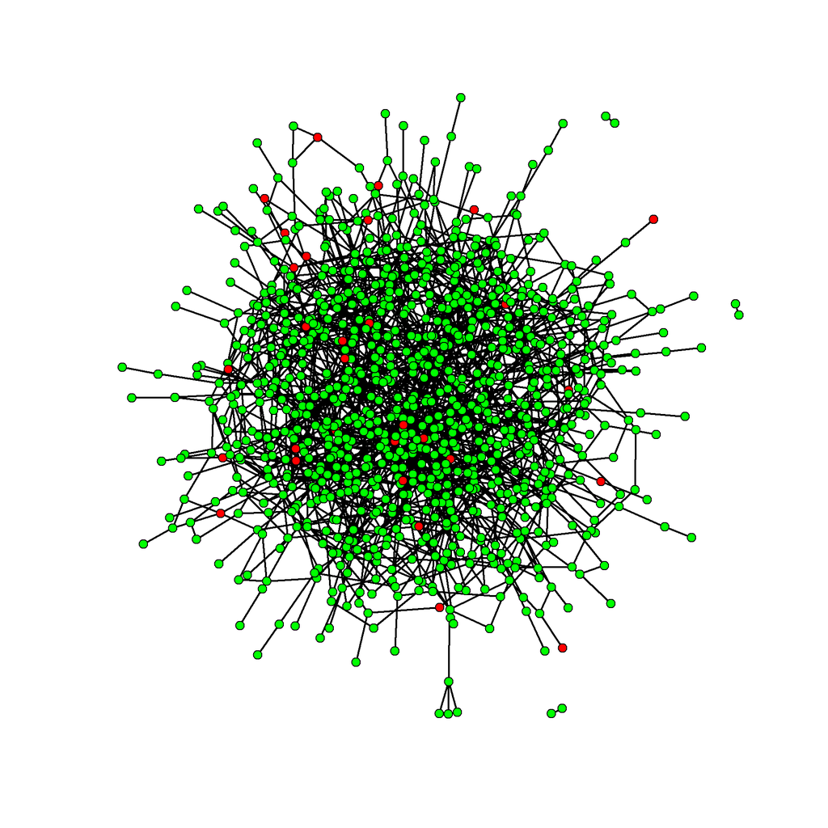

```r
V(net)$color <- V(net)$churn

V(net)$color <- str_replace(V(net)$color, "1", "red")
V(net)$color <- str_replace(V(net)$color, "0", "green")

plot(net, vertex.label=NA,
     vertex.size = 3,
     edge.color = 'black',
     edge.width = 2)
```

# 2 고객/HR 이탈 네트워크 데이터

## 2.1 노드 Feature

노드 관련 측도에 대한 자세한 설명은 [xwMOOC 네트워크 - 네트워크 기술통계](https://statkclee.github.io/network/tidygraph-descriptive-stat.html)을 참조한다.

```r
V(net)$degree <- degree(net, normalized=TRUE)
second_degree <- neighborhood.size(net, 2)
V(net)$second_degree <- second_degree / (length(V(net)) - 1)

V(net)$triangles <- count_triangles(net)

V(net)$betweenness <- betweenness(net, normalized=TRUE)
V(net)$closeness <- closeness(net, normalized=TRUE)
V(net)$eigen <- eigen_centrality(net, scale = TRUE)$vector

V(net)$transitivity <- transitivity(net, type="local", isolates='zero')

V(net)$pr <- page.rank(net)$vector
```

## 2.3 데이터프레임 변환

노드에 대한 다양한 통계량이 준비되면, `as_data_frame()` 함수를 통해서 네트워크 객체를 데이터프레임으로 변환한다.

```r
network_dat <- as_data_frame(net, what = "vertices") %>%
  tbl_df()

network_df <- network_dat %>%
  tbl_df() %>%
  select(-name, -color) %>%
  mutate(churn = ifelse(churn == 1, "yes", "no")) %>%
  mutate(churn = factor(churn, levels=c("yes","no"))) %>%
  filter(complete.cases(.))
```

# 3 예측모형

## 3.1 예측모형 적합

네트워크 객체를 데이터프레임으로 변환한 후 `caret` 팩키지 일반적인 예측모형 방법론과 절차에 따라 작업해 나간다.

```r
# 2. 예측모형 -----
## 2.1. 훈련/시험 데이터 분할 ------
library(caret)

network_index <- createDataPartition(network_df$churn, times =1, p=0.7, list=FALSE)

train_df <- network_df[network_index, ]
test_df  <- network_df[-network_index, ]

## 2.2. 모형 개발/검증 데이터셋 준비 ------

cv_folds <- createMultiFolds(train_df$churn, k = 10, times = 3)

cv_cntrl <- trainControl(method = "repeatedcv", number = 10,
                         repeats = 3,
                         sampling = "down",
                         summaryFunction = twoClassSummary,
                         classProbs = TRUE,
                         index = cv_folds)


## 2.2. 모형 개발/검증 데이터셋 준비 ------
library(doSNOW)
# 실행시간
start.time <- Sys.time()

cl <- makeCluster(4, type = "SOCK")
registerDoSNOW(cl)

churn_glm   <- train(churn ~ ., data = train_df,
                    method = "glm",
                    family = "binomial",
                    metric='Sens',
                    trControl = cv_cntrl,
                    tuneLength = 7)

churn_rf    <- train(churn ~ ., data = train_df,
                   method = "rf",
                   trControl = cv_cntrl,
                   metric='Sens',
                   tuneLength = 7,
                   importance = TRUE)

stopCluster(cl)

total.time <- Sys.time() - start.time
total.time
```

```
Time difference of 14.28043 secs
```

## 3.2 예측모형 성능

네트워크 Feature만으로 고객 이탈 모형을 생성한 후에 성능을 확인한다.

```r
# 3. 예측모형 성능 -----
## GLM
glm_pred_df <- predict(churn_glm, newdata=test_df, type="prob") %>%
  tbl_df %>%
  mutate(class = factor(ifelse(yes > no, "yes", "no"), levels = c("yes", "no")),
         prob  = yes)

confusionMatrix(glm_pred_df$class, test_df$churn)
```

```
Confusion Matrix and Statistics

          Reference
Prediction yes  no
       yes   6 117
       no    3 160

               Accuracy : 0.5804
                 95% CI : (0.5209, 0.6383)
    No Information Rate : 0.9685
    P-Value [Acc > NIR] : 1

                  Kappa : 0.0343
 Mcnemar's Test P-Value : <2e-16

            Sensitivity : 0.66667
            Specificity : 0.57762
         Pos Pred Value : 0.04878
         Neg Pred Value : 0.98160
             Prevalence : 0.03147
         Detection Rate : 0.02098
   Detection Prevalence : 0.43007
      Balanced Accuracy : 0.62214

       'Positive' Class : yes
```

```r
## randomForest
rf_pred_df <- predict(churn_rf, newdata=test_df) %>%
  tbl_df %>%
  rename(class = value)

confusionMatrix(rf_pred_df$class, test_df$churn)
```

```
Confusion Matrix and Statistics

          Reference
Prediction yes  no
       yes   6 138
       no    3 139

               Accuracy : 0.507
                 95% CI : (0.4475, 0.5663)
    No Information Rate : 0.9685
    P-Value [Acc > NIR] : 1

                  Kappa : 0.0204
 Mcnemar's Test P-Value : <2e-16

            Sensitivity : 0.66667
            Specificity : 0.50181
         Pos Pred Value : 0.04167
         Neg Pred Value : 0.97887
             Prevalence : 0.03147
         Detection Rate : 0.02098
   Detection Prevalence : 0.50350
      Balanced Accuracy : 0.58424

       'Positive' Class : yes
```